# AnimationPlayer

## Your questions

### How can I set an animation to a specific point

The `seek()` function lets you pass in a time, and the current animation skips to that point. Another optional boolean determines whether to update the items to this point or not.

### When should I use an animation player

It can be difficult to choose between using a `Tween` and an `AnimationPlayer`. The `AnimationPlayer` does have a few key strengths.

It’s easier to animate lots of properties with an animation player than a tween. It’s also easier to tweak and see how playback looks in real-time. This is because you can test your animation in real-time without needing to launch the game. You also have greater control over how properties change with easings or lots of keys.

The biggest reason not to use an `AnimationPlayer` is if you’re animating a value that can change. For example, animating motion towards the mouse. An `AnimationPlayer` can’t figure out where the mouse is, so a tween is much better for this case. One option is to use an `AnimationPlayer` and a tween at the same time, you can even start the tween with the animation. This lets you handle complex animations and variable motion at the same time.

The `AnimationPlayer` can greatly reduce the amount of code you need, so it’s best to use them when you can.

### Resetting my scene after playing animations

Playing an animation directly changes the properties of nodes in your scene. When you save the scene, the animated properties get saved in their current state too.

This is part of the system’s power, as it allows you to save an animation’s state for free in a game or plugin, but it is also a bit of a curse when working on your game.

To work around that, you can create an animation that resets your scene to its default values. We typically name it “SETUP.”

This animation should have a duration of `0` seconds. You can set it to autoplay to ensure all your nodes are ready at runtime.

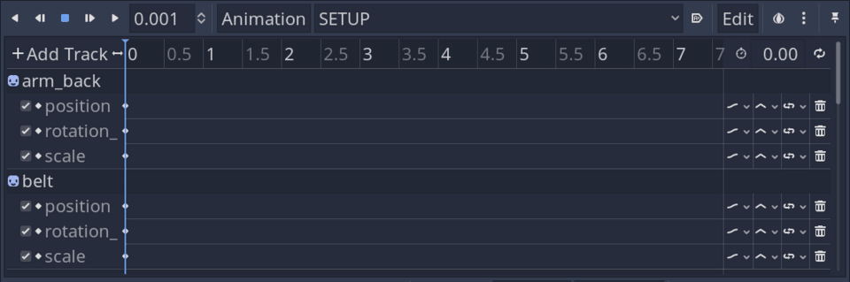

In this animation, you create one keyframe for every property your other animations affect.

Whenever you need to reset your scene’s state, change the current animation to “SETUP.”

### How to animate any value with an AnimationPlayer

An `AnimationPlayer` can’t set some properties. For example, the properties of an audio bus or the engine’s `time_scale`.

Thankfully, we can get around this with a script.

In this example, we export a property to animate the engine’s `time_scale`, which allows us to slow time.

In a script, we export a variable to control the target property. Then, we use the `setget` keyword to define a setter function.

In this function, we update the property that’s not accessible to the `AnimationPlayer`.

```
## Wrapper around the engine's time scale. Allows us to slow time in the
## animation player.
export var time_scale := 1.0 setget set_time_scale


func set_time_scale(value: float) -> void:
    time_scale = value
    # Thanks to this setter function, we can access the engine's properties.
    Engine.time_scale = time_scale
```

Now, our `AnimationPlayer` can access and animate that node’s `time_scale`, which, in turn, animates the engine’s time scale.

[figure not shown]

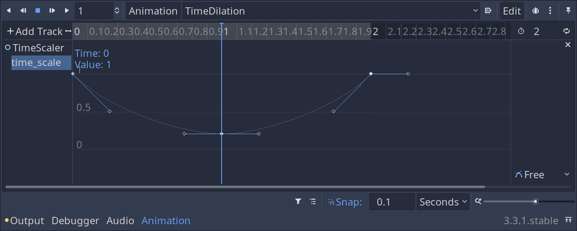

**Note:** While you could call a method directly with a *Call Method Track*, unlike with a property, you wouldn’t benefit from the interpolation.

### Saving and loading animations

You can save an animation and load it in another `AnimationPlayer` for reuse.

To do so, in the `Animation` bottom panel:

- Click *Animation -> Save As…*.
- Save the file in your project.

You can now use *Animation -> Load* in another `AnimationPlayer` to reuse the animation.

It’s worth noting that the animation uses relative paths and node names to animate. As a result, you need to have the same node paths and names in the scene you reuse the animation.

You can, however, easily change an animation track’s node and property path. You just have to click the property name in the `Animation` bottom panel.

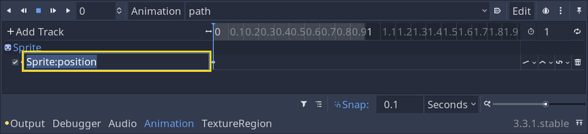

The paths have the form `Path/To/Node:path/to/property`. Note the node path can be `.` (a single dot), which targets the `AnimationPlayer`’s parent. And `..` targets the `AnimationPlayer`’s grandparent.

You can also duplicate and rename animations to copy them quickly.

There’s also an option to copy and paste an animation in the *Animation* menu.

However, as an animation is a Godot `Resource` under the hood, animations you copy and paste point to the same `Animation` resource in memory. As a result, modifying one copy causes the other animation to change accordingly.

To avoid that, use the *Animation -> Duplicate* option instead.